# Formative Exercise 09: MSc Data Skills Course

Psychology, University of Glasgow

## The `iris` dataset

There is a built-in dataset called `iris` that has measurements of different parts of flowers. (See `?iris` for information about the dataset.)

### Question 1

Use ggplot2 to make a scatterplot that visualizes the relationship between sepal length (horizontal axis) and petal width (vertical axis). Watch out for overplotting.

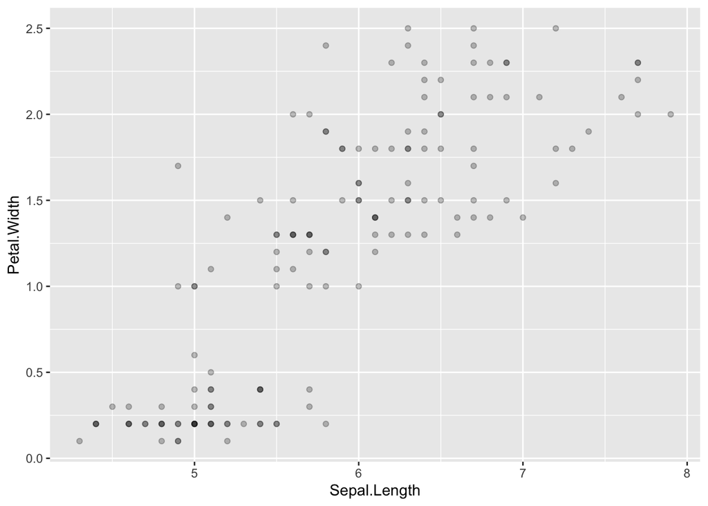

```r
ggplot(iris, aes(Sepal.Length, Petal.Width)) +
  geom_point(alpha = .25)
```

### Question 2

Run a regression model that predicts the petal width from the sepal length, and store the model object in the variable `iris_mod`. End the block by printing out the summary of the model.

```r
iris_mod <- lm(Petal.Width ~ Sepal.Length, iris)

summary(iris_mod) #print out the model summary
```

```
##
## Call:
## lm(formula = Petal.Width ~ Sepal.Length, data = iris)
##
## Residuals:
##      Min       1Q   Median       3Q      Max
## -0.96671 -0.35936 -0.01787  0.28388  1.23329
##
## Coefficients:
##              Estimate Std. Error t value Pr(>|t|)
## (Intercept)  -3.20022    0.25689  -12.46   <2e-16 ***
## Sepal.Length  0.75292    0.04353   17.30   <2e-16 ***
## ---
## Signif. codes:  0 '***' 0.001 '**' 0.01 '*' 0.05 '.' 0.1 ' ' 1
##
## Residual standard error: 0.44 on 148 degrees of freedom
## Multiple R-squared:  0.669,  Adjusted R-squared:  0.6668
## F-statistic: 299.2 on 1 and 148 DF,  p-value: < 2.2e-16
```

### Question 3

Make a histogram of the residuals of the model using ggplot2.

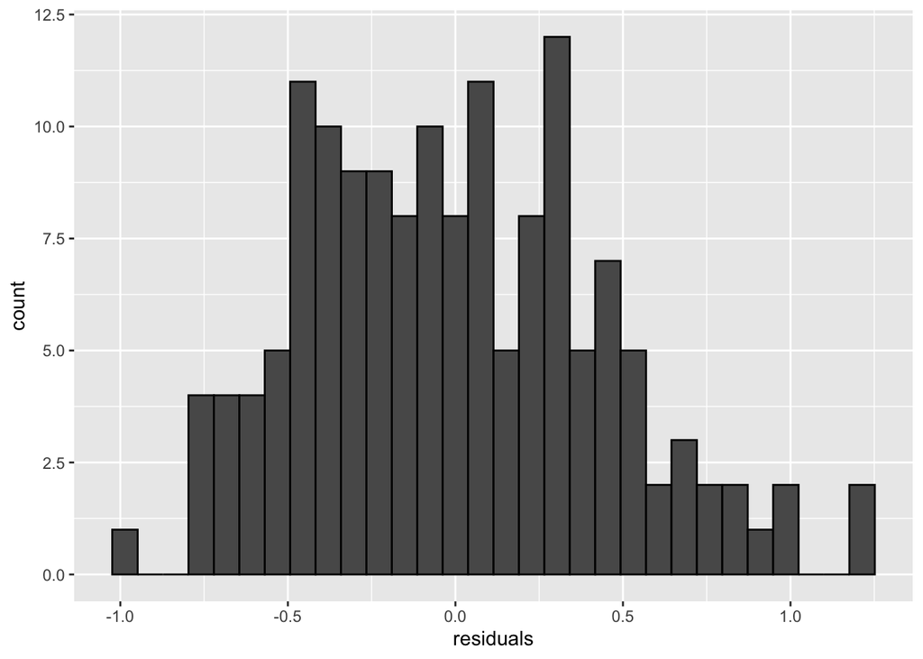

```r
residuals <- residuals(iris_mod)

ggplot() +
  geom_histogram(aes(residuals), color = "black")
```

### Question 4

Write code to predict the petal width for two plants, the first with a sepal length of 5.25cm, and the second with a sepal length of 6.3cm. Store the vector of predictions in the variable `iris_pred`.

```r
iris_pred <- predict(iris_mod, tibble(Sepal.Length = c(5.25, 6.3)))

iris_pred # print the predicted values
```

```
##         1         2
## 0.7526022 1.5431657
```

## Simulating data from the linear model

### Question 5

*NOTE: You can knit this file to html to see formatted versions of the equations below (which are enclosed in `$` characters); alternatively, if you find it easier, you can hover your mouse pointer over the `$` in the code equations to see the formatted versions.*

Write code to randomly generate 10 Y values from a simple linear regression model with an intercept of 3 and a slope of -7. Recall the form of the linear model:

$Y_i = \beta_0 + \beta_1 X_i + e_i$

The residuals ($e_i$s) are drawn from a normal distribution with mean 0 and variance $\sigma^2 = 4$, and $X$ is the vector of integer values from 1 to 10. Store the 10 observations in the variable `Yi` below. (NOTE: the standard deviation is the *square root* of the variance, i.e. $\sigma$; `rnorm()` takes the standard deviation, not the variance, as its third argument).

```r
X <- 1:10
err <- rnorm(10, sd = 2)
Yi <- 3 - 7 * X + err

Yi # print the values of Yi
```

```
##  [1]  -0.7426784  -7.7594656 -20.9941041 -22.8379955 -31.3152752
##  [6] -40.3503036 -45.3260546 -51.4067219 -60.7134652 -68.6375608
```

## Advanced

### Question 6

Write a function to simulate data with the form.

$Y_i = \beta_0 + \beta_1 X_i + e_i$

The function should take arguments for the number of observations to return (`n`), the intercept (`b0`), the effect (`b1`), the mean and SD of the predictor variable X (`X_mu` and `X_sd`), and the SD of the residual error (`err_sd`). The function should return a tibble with `n` rows and the columns `id`, `X` and `Y`.

```r
sim_lm_data <- function(n = 100, b0 = 0, b1 = 0,
                        X_mu = 0, X_sd = 1, err_sd = 1) {
  tibble(
    id = 1:n,
    X = rnorm(n, X_mu, X_sd),
    err = rnorm(n, 0, err_sd),
    Y = b0 + b1*X + err
  ) %>%
    select(id, X, Y)
}

dat6 <- sim_lm_data(n = 10) # do not edit

knitr::kable(dat6) # print table
```

| id | X | Y |
| --- | --- | --- |
| 1 | -0.2677796 | -1.1495673 |
| 2 | -0.3635290 | 1.2939085 |
| 3 | 1.0291560 | -0.4317920 |
| 4 | -0.2638047 | 0.3443449 |
| 5 | 0.4261811 | -0.4751273 |
| 6 | 1.2697468 | 0.7615962 |
| 7 | -2.4711206 | 0.0701522 |
| 8 | -0.8314822 | 0.4079785 |
| 9 | 0.5470372 | -1.0239402 |
| 10 | 0.0803618 | 1.2476843 |

### Question 7

Use the function from Question 6 to generate a data table with 10000 subjects, an intercept of 80, an effect of X of 0.5, where X has a mean of 0 and SD of 1, and residual error SD of 2.

Analyse the data with `lm()`. Find where the analysis summary estimates the values of `b0` and `b1`. What happens if you change the simulation values?

```r
dat7 <- sim_lm_data(n = 10000, b0 = 80, b1 = 0.5,
                   X_mu = 0, X_sd = 1, err_sd = 2)

mod7 <- lm(Y ~ X, data = dat7)

summary(mod7) # print summary
```

```
##
## Call:
## lm(formula = Y ~ X, data = dat7)
##
## Residuals:
##     Min      1Q  Median      3Q     Max
## -7.5128 -1.3554  0.0174  1.3832  7.2877
##
## Coefficients:
##             Estimate Std. Error t value Pr(>|t|)
## (Intercept) 80.00069    0.02015 3970.43   <2e-16 ***
## X            0.51867    0.02012   25.77   <2e-16 ***
## ---
## Signif. codes:  0 '***' 0.001 '**' 0.01 '*' 0.05 '.' 0.1 ' ' 1
##
## Residual standard error: 2.015 on 9998 degrees of freedom
## Multiple R-squared:  0.0623, Adjusted R-squared:  0.06221
## F-statistic: 664.3 on 1 and 9998 DF,  p-value: < 2.2e-16
```

### Question 8

Use the function from Question 6 to calculate power by simulation for the effect of X on Y in a design with 50 subjects, an intercept of 80, an effect of X of 0.5, where X has a mean of 0 and SD of 1, residual error SD of 2, and alpha of 0.05.

Hint: use `broom::tidy()` to get the p-value for the effect of X.

```r
# ... lets you include any arguments to send to sim_lm_data()
sim_lm_power <- function(...) {
  dat <- sim_lm_data(...)
  lm(Y~X, dat) %>%
    broom::tidy() %>%
    filter(term == "X") %>%
    pull(p.value)
}

p_values <- replicate(1000, sim_lm_power(n = 50, b0 = 80, b1 = 0.5, X_mu = 0, X_sd = 1, err_sd = 2))

power <- mean(p_values < .05)

power # print the value
```

```
## [1] 0.403
```

### Question 9

Calculate power (i.e., the false positive rate) for the effect of X on Y in a design with 50 subjects where there is no effect and alpha is 0.05.

```r
p_values <- replicate(1000, sim_lm_power(n = 50))

false_pos <- mean(p_values < .05)

false_pos # print the value
```

```
## [1] 0.046
```